# Libraries

```python
import pandas as pd
import numpy as np
import matplotlib.pyplot as plt
from sklearn.feature_extraction.text import TfidfVectorizer
from sklearn. metrics.pairwise import linear_kernel

# Plot graph
import matplotlib.pyplot as plt
import seaborn as sns
from collections import Counter

# Packages for Models
from sklearn.model_selection import train_test_split
from sklearn.ensemble import RandomForestClassifier
from sklearn.tree import DecisionTreeClassifier
from sklearn.neighbors import KNeighborsClassifier
from sklearn. metrics import *

import warnings
warnings.filterwarnings("ignore")
```

# Data Retrieval

```python
import pandas as pd

# Correct file path
file_path = r'D:\User\Saru\investments_VC.csv'

# Load the file with encoding specified
try:
    df = pd.read_csv(file_path, encoding='latin1')  # You can also try 'ISO-8859-1' if this doesn't work
    print("File loaded successfully!")
    print(df.head())  # Display the first few rows of the data frame
except FileNotFoundError:
    print("File not found. Please verify the file path.")
except Exception as e:
    print(f"An error occurred: {e}")
```

```
File loaded successfully!
                         permalink                name  \
0            /organization/waywire            #waywire
1  /organization/tv-communications  &TV Communications
2    /organization/rock-your-paper   'Rock' Your Paper
3   /organization/in-touch-network   (In)Touch Network
4   /organization/r-ranch-and-mine  -R- Ranch and Mine

                    homepage_url  \
0         http://www.waywire.com
1          http://enjoyandtv.com
2   http://www.rockyourpaper.org
3  http://www.InTouchNetwork.com
4                            NaN

```

[output cut: 29 more lines]

```python
df
```

|  | permalink | name | homepage_url | category_list | market | funding_total_usd | status | country_code | state_code | region | ... | secondary_market | product_crowdfunding | round_A | round_B | round_C | round_D | round_E | round_F | round_G | round_H |
| --- | --- | --- | --- | --- | --- | --- | --- | --- | --- | --- | --- | --- | --- | --- | --- | --- | --- | --- | --- | --- | --- |
| 0 | /organization/waywire | #waywire | http://www.waywire.com | \|Entertainment\|Politics\|Social Media\|News\| | News | 17,50,000 | acquired | USA | NY | New York City | ... | 0.0 | 0.0 | 0.0 | 0.0 | 0.0 | 0.0 | 0.0 | 0.0 | 0.0 | 0.0 |
| 1 | /organization/tv-communications | &TV Communications | http://enjoyandtv.com | \|Games\| | Games | 40,00,000 | operating | USA | CA | Los Angeles | ... | 0.0 | 0.0 | 0.0 | 0.0 | 0.0 | 0.0 | 0.0 | 0.0 | 0.0 | 0.0 |
| 2 | /organization/rock-your-paper | 'Rock' Your Paper | http://www.rockyourpaper.org | \|Publishing\|Education\| | Publishing | 40,000 | operating | EST | NaN | Tallinn | ... | 0.0 | 0.0 | 0.0 | 0.0 | 0.0 | 0.0 | 0.0 | 0.0 | 0.0 | 0.0 |
| 3 | /organization/in-touch-network | (In)Touch Network | http://www.InTouchNetwork.com | \|Electronics\|Guides\|Coffee\|Restaurants\|Music\|i... | Electronics | 15,00,000 | operating | GBR | NaN | London | ... | 0.0 | 0.0 | 0.0 | 0.0 | 0.0 | 0.0 | 0.0 | 0.0 | 0.0 | 0.0 |
| 4 | /organization/r-ranch-and-mine | -R- Ranch and Mine | NaN | \|Tourism\|Entertainment\|Games\| | Tourism | 60,000 | operating | USA | TX | Dallas | ... | 0.0 | 0.0 | 0.0 | 0.0 | 0.0 | 0.0 | 0.0 | 0.0 | 0.0 | 0.0 |
| ... | ... | ... | ... | ... | ... | ... | ... | ... | ... | ... | ... | ... | ... | ... | ... | ... | ... | ... | ... | ... | ... |
| 54289 | NaN | NaN | NaN | NaN | NaN | NaN | NaN | NaN | NaN | NaN | ... | NaN | NaN | NaN | NaN | NaN | NaN | NaN | NaN | NaN | NaN |
| 54290 | NaN | NaN | NaN | NaN | NaN | NaN | NaN | NaN | NaN | NaN | ... | NaN | NaN | NaN | NaN | NaN | NaN | NaN | NaN | NaN | NaN |
| 54291 | NaN | NaN | NaN | NaN | NaN | NaN | NaN | NaN | NaN | NaN | ... | NaN | NaN | NaN | NaN | NaN | NaN | NaN | NaN | NaN | NaN |
| 54292 | NaN | NaN | NaN | NaN | NaN | NaN | NaN | NaN | NaN | NaN | ... | NaN | NaN | NaN | NaN | NaN | NaN | NaN | NaN | NaN | NaN |
| 54293 | NaN | NaN | NaN | NaN | NaN | NaN | NaN | NaN | NaN | NaN | ... | NaN | NaN | NaN | NaN | NaN | NaN | NaN | NaN | NaN | NaN |

54294 rows × 39 columns

# Data Cleaning

```python
len(df)
```

```
54294
```

```python
df.tail()
```

|  | permalink | name | homepage_url | category_list | market | funding_total_usd | status | country_code | state_code | region | ... | secondary_market | product_crowdfunding | round_A | round_B | round_C | round_D | round_E | round_F | round_G | round_H |
| --- | --- | --- | --- | --- | --- | --- | --- | --- | --- | --- | --- | --- | --- | --- | --- | --- | --- | --- | --- | --- | --- |
| 54289 | NaN | NaN | NaN | NaN | NaN | NaN | NaN | NaN | NaN | NaN | ... | NaN | NaN | NaN | NaN | NaN | NaN | NaN | NaN | NaN | NaN |
| 54290 | NaN | NaN | NaN | NaN | NaN | NaN | NaN | NaN | NaN | NaN | ... | NaN | NaN | NaN | NaN | NaN | NaN | NaN | NaN | NaN | NaN |
| 54291 | NaN | NaN | NaN | NaN | NaN | NaN | NaN | NaN | NaN | NaN | ... | NaN | NaN | NaN | NaN | NaN | NaN | NaN | NaN | NaN | NaN |
| 54292 | NaN | NaN | NaN | NaN | NaN | NaN | NaN | NaN | NaN | NaN | ... | NaN | NaN | NaN | NaN | NaN | NaN | NaN | NaN | NaN | NaN |
| 54293 | NaN | NaN | NaN | NaN | NaN | NaN | NaN | NaN | NaN | NaN | ... | NaN | NaN | NaN | NaN | NaN | NaN | NaN | NaN | NaN | NaN |

5 rows × 39 columns

```python
## select only data which name is not null

df = df[~df.name.isna()]
```

```python
df = df[~df.name.isna()]
len(df)
```

```
49437
```

```python
df.name.isna()
```

```
0        False
1        False
2        False
3        False
4        False
         ...
49433    False
49434    False
49435    False
49436    False
49437    False
Name: name, Length: 49437, dtype: bool
```

```python
len(df)
```

```
49437
```

Okay..., we have around 49437 companies left in our dataset

```python
df.info()
```

```
<class 'pandas.core.frame.DataFrame'>
Index: 49437 entries, 0 to 49437
Data columns (total 39 columns):
 #   Column                Non-Null Count  Dtype
---  ------                --------------  -----
 0   permalink             49437 non-null  object
 1   name                  49437 non-null  object
 2   homepage_url          45988 non-null  object
 3   category_list         45476 non-null  object
 4    market               45469 non-null  object
 5    funding_total_usd    49437 non-null  object
 6   status                48123 non-null  object
 7   country_code          44165 non-null  object
 8   state_code            30161 non-null  object
 9   region                44165 non-null  object
```

[output cut: 31 more lines]

```python
df.head()
```

|  | permalink | name | homepage_url | category_list | market | funding_total_usd | status | country_code | state_code | region | ... | secondary_market | product_crowdfunding | round_A | round_B | round_C | round_D | round_E | round_F | round_G | round_H |
| --- | --- | --- | --- | --- | --- | --- | --- | --- | --- | --- | --- | --- | --- | --- | --- | --- | --- | --- | --- | --- | --- |
| 0 | /organization/waywire | #waywire | http://www.waywire.com | \|Entertainment\|Politics\|Social Media\|News\| | News | 17,50,000 | acquired | USA | NY | New York City | ... | 0.0 | 0.0 | 0.0 | 0.0 | 0.0 | 0.0 | 0.0 | 0.0 | 0.0 | 0.0 |
| 1 | /organization/tv-communications | &TV Communications | http://enjoyandtv.com | \|Games\| | Games | 40,00,000 | operating | USA | CA | Los Angeles | ... | 0.0 | 0.0 | 0.0 | 0.0 | 0.0 | 0.0 | 0.0 | 0.0 | 0.0 | 0.0 |
| 2 | /organization/rock-your-paper | 'Rock' Your Paper | http://www.rockyourpaper.org | \|Publishing\|Education\| | Publishing | 40,000 | operating | EST | NaN | Tallinn | ... | 0.0 | 0.0 | 0.0 | 0.0 | 0.0 | 0.0 | 0.0 | 0.0 | 0.0 | 0.0 |
| 3 | /organization/in-touch-network | (In)Touch Network | http://www.InTouchNetwork.com | \|Electronics\|Guides\|Coffee\|Restaurants\|Music\|i... | Electronics | 15,00,000 | operating | GBR | NaN | London | ... | 0.0 | 0.0 | 0.0 | 0.0 | 0.0 | 0.0 | 0.0 | 0.0 | 0.0 | 0.0 |
| 4 | /organization/r-ranch-and-mine | -R- Ranch and Mine | NaN | \|Tourism\|Entertainment\|Games\| | Tourism | 60,000 | operating | USA | TX | Dallas | ... | 0.0 | 0.0 | 0.0 | 0.0 | 0.0 | 0.0 | 0.0 | 0.0 | 0.0 | 0.0 |

5 rows × 39 columns

Deal with NaN values and Encode Categorical Features

```python
df.isna().sum()
```

```
permalink                   0
name                        0
homepage_url             3449
category_list            3961
 market                  3968
 funding_total_usd          0
status                   1314
country_code             5272
state_code              19276
region                   5272
city                     6115
funding_rounds              0
founded_at              10884
founded_month           10956
founded_quarter         10956
founded_year            10956
first_funding_at            0
last_funding_at             0
seed                        0
venture                     0
equity_crowdfunding         0
undisclosed                 0
convertible_note            0
debt_financing              0
angel                       0
grant                       0
private_equity              0
post_ipo_equity             0
post_ipo_debt               0
secondary_market            0
product_crowdfunding        0
round_A                     0
round_B                     0
round_C                     0
round_D                     0
round_E                     0
round_F                     0
round_G                     0
round_H                     0
dtype: int64
```

```python
print( df.columns.values )
```

```
['permalink' 'name' 'homepage_url' 'category_list' ' market '
 ' funding_total_usd ' 'status' 'country_code' 'state_code' 'region'
 'city' 'funding_rounds' 'founded_at' 'founded_month' 'founded_quarter'
 'founded_year' 'first_funding_at' 'last_funding_at' 'seed' 'venture'
 'equity_crowdfunding' 'undisclosed' 'convertible_note' 'debt_financing'
 'angel' 'grant' 'private_equity' 'post_ipo_equity' 'post_ipo_debt'
 'secondary_market' 'product_crowdfunding' 'round_A' 'round_B' 'round_C'
 'round_D' 'round_E' 'round_F' 'round_G' 'round_H']
```

From those columns above, I will select "status", "market", "funding total usd", "founded at" , "country code" to do some roughly describe the dataset

# Warning

some column name contains space in string, I decide to remove them first.

```python
df.rename(columns={' funding_total_usd ': "funding_total_usd",
                    ' market ': "market"},inplace=True)
```

# status

```python
df['status'].value_counts()
```

```
status
operating    41829
acquired      3692
closed        2602
Name: count, dtype: int64
```

```python
df.describe()
```

|  | funding_rounds | founded_year | seed | venture | equity_crowdfunding | undisclosed | convertible_note | debt_financing | angel | grant | ... | secondary_market | product_crowdfunding | round_A | round_B | round_C | round_D | round_E | round_F | round_G | round_H |
| --- | --- | --- | --- | --- | --- | --- | --- | --- | --- | --- | --- | --- | --- | --- | --- | --- | --- | --- | --- | --- | --- |
| count | 49437.000000 | 38481.000000 | 4.943700e+04 | 4.943700e+04 | 4.943700e+04 | 4.943700e+04 | 4.943700e+04 | 4.943700e+04 | 4.943700e+04 | 4.943700e+04 | ... | 4.943700e+04 | 4.943700e+04 | 4.943700e+04 | 4.943700e+04 | 4.943700e+04 | 4.943700e+04 | 4.943700e+04 | 4.943700e+04 | 4.943700e+04 | 4.943700e+04 |
| mean | 1.696219 | 2007.359034 | 2.173254e+05 | 7.501202e+06 | 6.163447e+03 | 1.302239e+05 | 2.336457e+04 | 1.888195e+06 | 6.542030e+04 | 1.628486e+05 | ... | 3.845670e+04 | 7.074370e+03 | 1.243980e+06 | 1.492921e+06 | 1.205380e+06 | 7.375410e+05 | 3.424751e+05 | 1.697726e+05 | 5.767183e+04 | 1.423226e+04 |
| std | 1.294222 | 7.579279 | 1.056995e+06 | 2.847139e+07 | 1.999068e+05 | 2.981434e+06 | 1.432060e+06 | 1.382060e+08 | 6.582974e+05 | 5.612145e+06 | ... | 3.864500e+06 | 4.282209e+05 | 5.532027e+06 | 7.472777e+06 | 7.993671e+06 | 9.815317e+06 | 5.406969e+06 | 6.277969e+06 | 5.252365e+06 | 2.716893e+06 |
| min | 1.000000 | 1902.000000 | 0.000000e+00 | 0.000000e+00 | 0.000000e+00 | 0.000000e+00 | 0.000000e+00 | 0.000000e+00 | 0.000000e+00 | 0.000000e+00 | ... | 0.000000e+00 | 0.000000e+00 | 0.000000e+00 | 0.000000e+00 | 0.000000e+00 | 0.000000e+00 | 0.000000e+00 | 0.000000e+00 | 0.000000e+00 | 0.000000e+00 |
| 25% | 1.000000 | 2006.000000 | 0.000000e+00 | 0.000000e+00 | 0.000000e+00 | 0.000000e+00 | 0.000000e+00 | 0.000000e+00 | 0.000000e+00 | 0.000000e+00 | ... | 0.000000e+00 | 0.000000e+00 | 0.000000e+00 | 0.000000e+00 | 0.000000e+00 | 0.000000e+00 | 0.000000e+00 | 0.000000e+00 | 0.000000e+00 | 0.000000e+00 |
| 50% | 1.000000 | 2010.000000 | 0.000000e+00 | 0.000000e+00 | 0.000000e+00 | 0.000000e+00 | 0.000000e+00 | 0.000000e+00 | 0.000000e+00 | 0.000000e+00 | ... | 0.000000e+00 | 0.000000e+00 | 0.000000e+00 | 0.000000e+00 | 0.000000e+00 | 0.000000e+00 | 0.000000e+00 | 0.000000e+00 | 0.000000e+00 | 0.000000e+00 |
| 75% | 2.000000 | 2012.000000 | 2.500000e+04 | 5.000000e+06 | 0.000000e+00 | 0.000000e+00 | 0.000000e+00 | 0.000000e+00 | 0.000000e+00 | 0.000000e+00 | ... | 0.000000e+00 | 0.000000e+00 | 0.000000e+00 | 0.000000e+00 | 0.000000e+00 | 0.000000e+00 | 0.000000e+00 | 0.000000e+00 | 0.000000e+00 | 0.000000e+00 |
| max | 18.000000 | 2014.000000 | 1.300000e+08 | 2.351000e+09 | 2.500000e+07 | 2.924328e+08 | 3.000000e+08 | 3.007950e+10 | 6.359026e+07 | 7.505000e+08 | ... | 6.806116e+08 | 7.200000e+07 | 3.190000e+08 | 5.420000e+08 | 4.900000e+08 | 1.200000e+09 | 4.000000e+08 | 1.060000e+09 | 1.000000e+09 | 6.000000e+08 |

8 rows × 23 columns

```python
# Describing a non Numerical Data
df.describe(exclude=[np.number])
```

|  | permalink | name | homepage_url | category_list | market | funding_total_usd | status | country_code | state_code | region | city | founded_at | founded_month | founded_quarter | first_funding_at | last_funding_at |
| --- | --- | --- | --- | --- | --- | --- | --- | --- | --- | --- | --- | --- | --- | --- | --- | --- |
| count | 49437 | 49437 | 45988 | 45476 | 45469 | 49437 | 48123 | 44165 | 30161 | 44165 | 43322 | 38553 | 38481 | 38481 | 49437 | 49437 |
| unique | 49435 | 49350 | 45849 | 16675 | 753 | 14617 | 3 | 115 | 61 | 1089 | 4188 | 3369 | 420 | 218 | 3914 | 3657 |
| top | /organization/prysm | Roost | http://www.smartfocus.com | \|Software\| | Software | - | operating | USA | CA | SF Bay Area | San Francisco | 2012-01-01 | 2012-01 | 2012-Q1 | 2012-01-01 | 2013-01-01 |
| freq | 2 | 4 | 2 | 3650 | 4620 | 8531 | 41829 | 28793 | 9917 | 6804 | 2615 | 2181 | 2327 | 2904 | 468 | 387 |

```python
df.region
```

```
0        New York City
1          Los Angeles
2              Tallinn
3               London
4               Dallas
             ...
49433           London
49434          Beijing
49435            Split
49436              NaN
49437    New York City
Name: region, Length: 49437, dtype: object
```

```python
df.city == 'New York'
```

```
0         True
1        False
2        False
3        False
4        False
         ...
49433    False
49434    False
49435    False
49436    False
49437     True
Name: city, Length: 49437, dtype: bool
```

# Visualization

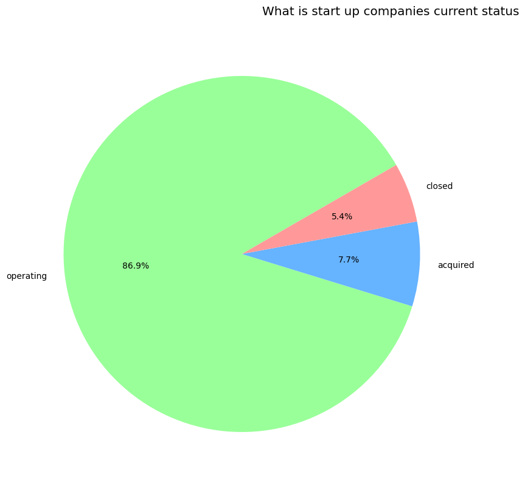

```python
plt.rcParams['figure.figsize'] = 8,8
labels = df['status'].value_counts().index.tolist()
sizes = df['status'].value_counts().tolist()
explode = (0, 0, 0.2)
colors = ['#99ff99','#66b3ff','#ff9999']

plt.pie(sizes, explode=None, labels=labels, colors=colors, autopct='%1.1f%%', shadow=False, startangle=30)
plt.axis('equal')
plt.tight_layout()
plt.title("What is start up companies current status", fontdict=None, position= [0.88,2], size = 'x-large')
plt.show()
```

Most of company (86.9 %) in this dataset is operating, and around 5.4 % company is already closed.

```python
len(df['market'].unique())
```

```
754
```

```python
df['market'].value_counts()[:15]
```

```
market
Software                4620
Biotechnology           3688
Mobile                  1983
E-Commerce              1805
Curated Web             1655
Enterprise Software     1280
Health Care             1207
Clean Technology        1200
Games                   1182
Hardware + Software     1081
Advertising             1064
Health and Wellness      920
Social Media             876
Finance                  867
Education                863
Name: count, dtype: int64
```

because we have around 754 categories of start up, Then just plot the top 15 : )

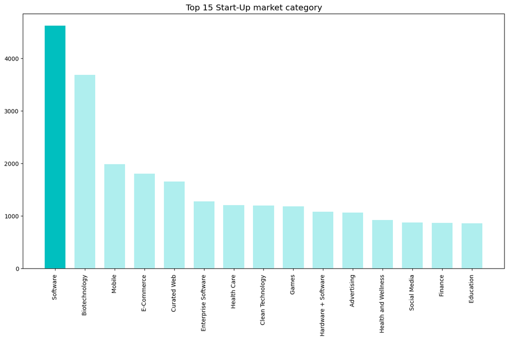

```python
plt.rcParams['figure.figsize'] = 15,8

height = df['market'].value_counts()[:15].tolist()
bars =  df['market'].value_counts()[:15].index.tolist()
y_pos = np.arange(len(bars))
plt.bar(y_pos, height , width=0.7 ,color= ['c']+['paleturquoise']*14)
plt.xticks(y_pos, bars)
plt.xticks(rotation=90)
plt.title("Top 15 Start-Up market category", fontdict=None, position= [0.48,1.05], size = 'x-large')
plt.show()
```

# Category

```python
df.category_list
```

```
0               |Entertainment|Politics|Social Media|News|
1                                                  |Games|
2                                   |Publishing|Education|
3        |Electronics|Guides|Coffee|Restaurants|Music|i...
4                            |Tourism|Entertainment|Games|
                               ...
49433    |Analytics|Gamification|Developer APIs|iOS|And...
49434                                |Enterprise Software|
49435        |Web Development|Advertising|Wireless|Mobile|
49436                                              |Games|
49437                                |Enterprise Software|
Name: category_list, Length: 49437, dtype: object
```

```python
set_keywords = set()
for liste_keywords in df['category_list'].str.split('|').values:
    if isinstance(liste_keywords, float): continue  # only happen if liste_keywords = NaN
    set_keywords = set_keywords.union(liste_keywords)
#_________________________
# remove null chain entry
set_keywords.remove('')
```

# Total Funding USD

```python
df['funding_total_usd'].head()
```

```
0     17,50,000
1     40,00,000
2        40,000
3     15,00,000
4        60,000
Name: funding_total_usd, dtype: object
```

Unlucky..., this column is provided in "string" format which contain comma(,) minus(-) and space ( ) we need to replace them and convert it to numeric format first

```python
df['funding_total_usd'] = df['funding_total_usd'].str.replace(',', '')
df['funding_total_usd'] = df['funding_total_usd'].str.replace('-', '')
df['funding_total_usd'] = df['funding_total_usd'].str.replace(' ', '')

df['funding_total_usd'] = pd.to_numeric(df['funding_total_usd'], errors='coerce')
```

```python
df['funding_total_usd'].head()
```

```
0    1750000.0
1    4000000.0
2      40000.0
3    1500000.0
4      60000.0
Name: funding_total_usd, dtype: float64
```

Okay..., let do some visualize

```python
Q1 = df['funding_total_usd'].quantile(0.25)
Q3 = df['funding_total_usd'].quantile(0.75)
IQR = Q3 - Q1

lower_bound = Q1 - 1.5 * IQR
upper_bound = Q3 + 1.5 * IQR
```

```python
without_outlier = df[(df['funding_total_usd'] > lower_bound ) & (df['funding_total_usd'] < upper_bound)]
```

```python
Facebook_total_funding = df['funding_total_usd'][df['name'] == "Facebook"].values[0]
Uber_total_funding = df['funding_total_usd'][df['name'] == "Uber"].values[0]
Alibaba_total_funding = df['funding_total_usd'][df['name'] == "Alibaba"].values[0]
Cloudera_total_funding = df['funding_total_usd'][df['name'] == "Cloudera"].values[0]
```

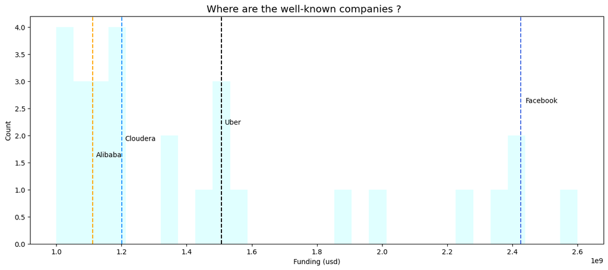

```python
plt.rcParams['figure.figsize'] = 15,6

plt.hist(df['funding_total_usd'][(df['funding_total_usd'] >= 1000000000)&(df['funding_total_usd'] <= 3000000000)].dropna(), bins=30,color = 'lightcyan' )
plt.ylabel('Count')
plt.xlabel('Funding (usd)')
plt.title("Where are the well-known companies ? ", fontdict=None, position= [0.48,1.05], size = 'x-large')

plt.axvline(Facebook_total_funding,color='royalblue',linestyle ="--")
plt.text(Facebook_total_funding+15000000, 2.6,"Facebook")

plt.axvline(Uber_total_funding,color='black',linestyle ="--")
plt.text(Uber_total_funding+10000000, 2.2,"Uber")

plt.axvline(Cloudera_total_funding,color='dodgerblue',linestyle ="--")
plt.text(Cloudera_total_funding+10000000, 1.9,"Cloudera")

plt.axvline(Alibaba_total_funding,color='orange',linestyle ="--")
plt.text(Alibaba_total_funding+10000000, 1.6,"Alibaba")




plt.show()
```

But..., Are they the highest funding ? the answer is no.

```python
Verizon_total_funding = df['funding_total_usd'][df['name'] == "Verizon Communications"].values[0]
Sberbank_total_funding = df['funding_total_usd'][df['name'] == "Sberbank"].values[0]
```

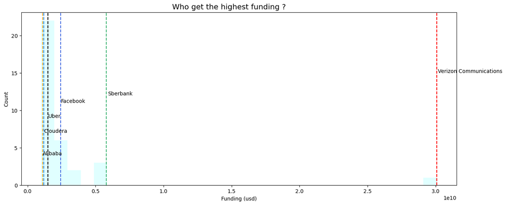

```python
plt.rcParams['figure.figsize'] = 15,6
plt.hist(df['funding_total_usd'][(df['funding_total_usd'] >= 1000000000)].dropna(), bins=30,color = 'lightcyan' )
plt.ylabel('Count')
plt.xlabel('Funding (usd)')
plt.title("Who get the highest funding ? ", fontdict=None, position= [0.48,1.05], size = 'x-large')

plt.axvline(Facebook_total_funding,color='royalblue',linestyle ="--")
plt.text(Facebook_total_funding+15000000, 11,"Facebook")

plt.axvline(Uber_total_funding,color='black',linestyle ="--")
plt.text(Uber_total_funding+10000000, 9,"Uber")

plt.axvline(Cloudera_total_funding,color='dodgerblue',linestyle ="--")
plt.text(Cloudera_total_funding+10000000, 7,"Cloudera")

plt.axvline(Alibaba_total_funding,color='orange',linestyle ="--")
plt.text(Alibaba_total_funding+10000000, 4,"Alibaba")

plt.axvline(Verizon_total_funding,color='red',linestyle ="--")
plt.text(Verizon_total_funding+100000000, 15,"Verizon Communications")

plt.axvline(Sberbank_total_funding,color='mediumseagreen',linestyle ="--")
plt.text(Sberbank_total_funding+100000000, 12,"Sberbank")


plt.show()
```

The most funding company in this dataset is "Verizon communication" which has total fund around 30,000,000,000 usd

```python
df['founded_at'].head()
```

```
0    2012-06-01
1           NaN
2    2012-10-26
3    2011-04-01
4    2014-01-01
Name: founded_at, dtype: object
```

This column is provided in term of string format which we need to convert to datetime first

```python
df['founded_at'] = pd.to_datetime(df['founded_at'], errors = 'coerce' )
```

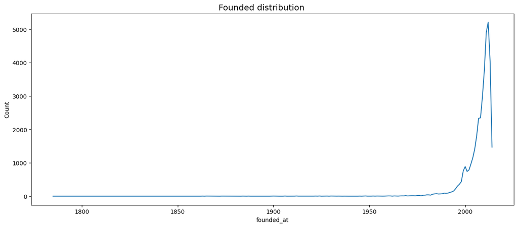

```python
plt.rcParams['figure.figsize'] = 15,6
df['name'].groupby(df["founded_at"].dt.year).count().plot(kind="line")

plt.ylabel('Count')
plt.title("Founded distribution ", fontdict=None, position= [0.48,1.05], size = 'x-large')
plt.show()
```

```python
Facebook_founded_year = df['founded_at'][df['name']=="Facebook"].dt.year.values[0]
Uber_founded_year  = df['founded_at'][df['name']=="Uber"].dt.year.values[0]
Alibaba_founded_year  = df['founded_at'][df['name']=="Alibaba"].dt.year.values[0]
```

```python
Uber_founded_year
```

```
2009
```

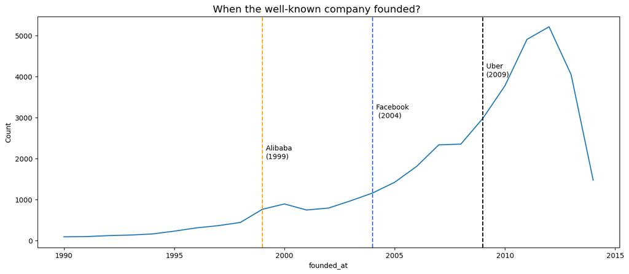

```python
plt.rcParams['figure.figsize'] = 15, 6
df['name'][df["founded_at"].dt.year >= 1990].groupby(df["founded_at"].dt.year).count().plot(kind="line")
plt.ylabel('Count')

plt.axvline(Facebook_founded_year, color='royalblue', linestyle="--")
plt.text(Facebook_founded_year + 0.15, 3000, "Facebook \n (2004)")

plt.axvline(Uber_founded_year, color='black', linestyle="--")
plt.text(Uber_founded_year + 0.15, 4000, "Uber \n(2009)")

plt.axvline(Alibaba_founded_year, color='orange', linestyle="--")
plt.text(Alibaba_founded_year + 0.15, 2000, "Alibaba \n(1999)")

plt.title("When the well-known company founded?", fontdict=None, position=[0.48, 1.05], size='x-large')
plt.show()
```

# Country Code

```python
len(df['country_code'].unique())
```

```
116
```

```python
df['country_code'].value_counts()[:20]
```

```
country_code
USA    28793
GBR     2642
CAN     1405
CHN     1239
DEU      968
FRA      866
IND      849
ISR      682
ESP      549
RUS      368
SWE      315
AUS      314
ITA      308
NLD      307
IRL      306
SGP      299
BRA      293
CHL      285
JPN      284
KOR      246
Name: count, dtype: int64
```

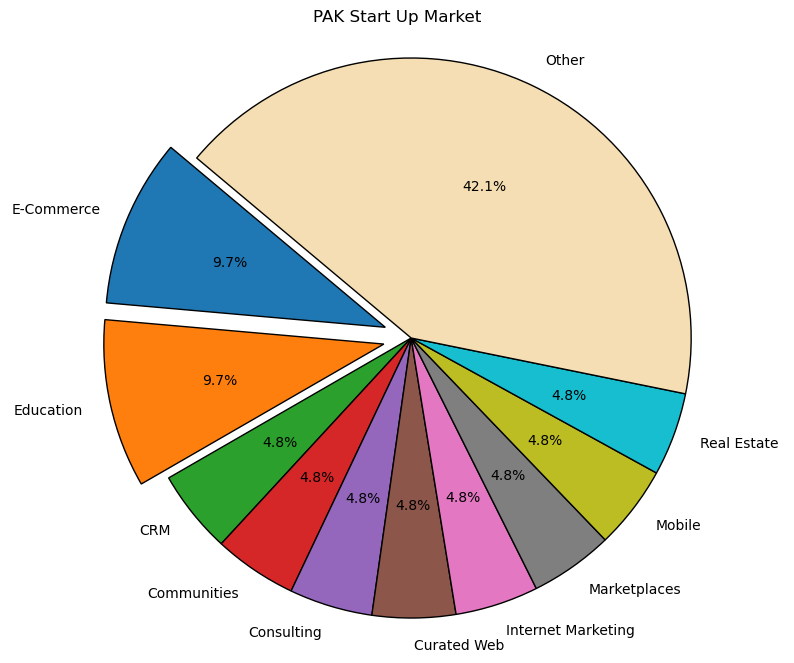

```python
import matplotlib.pyplot as plt

# Example data (replace this with your actual data)
labels = ['E-Commerce', 'Education', 'CRM', 'Communities', 'Consulting', 'Curated Web',
          'Internet Marketing', 'Marketplaces', 'Mobile', 'Real Estate', 'Other']
sizes = [9.7, 9.7, 4.8, 4.8, 4.8, 4.8, 4.8, 4.8, 4.8, 4.8, 42.0]  # Percentages
colors = ['#1f77b4', '#ff7f0e', '#2ca02c', '#d62728', '#9467bd', '#8c564b',
          '#e377c2', '#7f7f7f', '#bcbd22', '#17becf', '#f5deb3']  # Optional colors
explode = (0.1, 0.1, 0, 0, 0, 0, 0, 0, 0, 0, 0)  # Slightly explode the top 2 segments

# Create the pie chart
plt.figure(figsize=(10, 8))
plt.pie(sizes, explode=explode, labels=labels, colors=colors, autopct='%1.1f%%',
        startangle=140, wedgeprops={'edgecolor': 'black'})
plt.title('PAK Start Up Market')
plt.axis('equal')  # Equal aspect ratio ensures that pie is drawn as a circle.
plt.show()
```

# Funding Analysis

```python
warnings.filterwarnings("ignore")
pd.options.display.float_format = '{:.2f}'.format
## Function for providing summary in dataframe
%matplotlib inline

def funding_information(df,name):
    company = df[df['name'] == name]
    print ("Company : ", name)
    print ("Total Funding : ", company.funding_total_usd.values[0] , " $")
    print ("Seed Funding : ", company.seed.values[0] , " $")
    print ("Angle Funding :", company.angel.values[0] , " $")
    print ("Grant Funding : ",company.grant.values[0] , " $")
    print ("Product Crowd Funding : ",company.product_crowdfunding.values[0] , " $")
    print ("Equity Crowd Funding : ",company.equity_crowdfunding.values[0] , " $")
    print ("Undisclode Funding : ", company.undisclosed.values[0] , " $")
    print ("Convertible Note : ", company.convertible_note.values[0] , " $")
    print ("Debt Financing : ", company.debt_financing.values[0] , " $")
    print ("Private Equity : ",company.private_equity.values[0] , " $")
    print ("PostIPO Equity : ",company.post_ipo_equity.values[0] , " $")
    print ("PostIPO Debt : ",company.post_ipo_debt.values[0] , " $")
    print ("Secondary Market : ",company.secondary_market.values[0] , " $")
    print ("Venture Funding : ",company.venture.values[0] , " $")
    print ("Round A funding : ",company.round_A.values[0] , " $")
    print ("Round B funding : ",company.round_B.values[0] , " $")
    print ("Round C funding : ",company.round_C.values[0] , " $")
    print ("Round D funding : ",company.round_D.values[0] , " $")
    print ("Round E funding : ",company.round_E.values[0] , " $")
    print ("Round F funding : ",company.round_F.values[0] , " $")
    print ("Round G funding : ",company.round_G.values[0] , " $")
    print ("Round H funding : ",company.round_H.values[0] , " $")

def count_word(df, ref_col, liste):
    keyword_count = dict()
    for s in liste: keyword_count[s] = 0
    for liste_keywords in df[ref_col].str.split('|'):
        if type(liste_keywords) == float and pd.isnull(liste_keywords): continue
        for s in [s for s in liste_keywords if s in liste]:
            if pd.notnull(s): keyword_count[s] += 1
    #______________________________________________________________________
    # convert the dictionary in a list to sort the keywords by frequency
    keyword_occurences = []
    for k,v in keyword_count.items():
        keyword_occurences.append([k,v])
    keyword_occurences.sort(key = lambda x:x[1], reverse = True)
    return keyword_occurences, keyword_count


def makeCloud(Dict,name,color):
    words = dict()

    for s in Dict:
        words[s[0]] = s[1]

        wordcloud = WordCloud(
                      width=1500,
                      height=750,
                      background_color=color,
                      max_words=50,
                      max_font_size=500,
                      normalize_plurals=False)
        wordcloud.generate_from_frequencies(words)


    fig = plt.figure(figsize=(12, 8))
    plt.title(name)
    plt.imshow(wordcloud)
    plt.axis('off')

    plt.show()
```

```python
funding_information(df,"Dropbox")
```

```
Company :  Dropbox
Total Funding :  1107215000.0  $
Seed Funding :  15000.0  $
Angle Funding : 0.0  $
Grant Funding :  0.0  $
Product Crowd Funding :  0.0  $
Equity Crowd Funding :  0.0  $
Undisclode Funding :  0.0  $
Convertible Note :  0.0  $
Debt Financing :  500000000.0  $
Private Equity :  0.0  $
PostIPO Equity :  0.0  $
PostIPO Debt :  0.0  $
Secondary Market :  0.0  $
Venture Funding :  607200000.0  $
Round A funding :  7200000.0  $
Round B funding :  250000000.0  $
Round C funding :  350000000.0  $
Round D funding :  0.0  $
Round E funding :  0.0  $
Round F funding :  0.0  $
Round G funding :  0.0  $
Round H funding :  0.0  $
```

Here I have the print function to make data easier to consume, As you can see in "Dropbox" case, The total funding is 1,107,215,000 usd

For Venture Funding, this dataset also shows How much company get fund in each round.

```python
funding_information(df,"Uber")
```

```
Company :  Uber
Total Funding :  1507450000.0  $
Seed Funding :  200000.0  $
Angle Funding : 1250000.0  $
Grant Funding :  0.0  $
Product Crowd Funding :  0.0  $
Equity Crowd Funding :  0.0  $
Undisclode Funding :  0.0  $
Convertible Note :  0.0  $
Debt Financing :  0.0  $
Private Equity :  0.0  $
PostIPO Equity :  0.0  $
PostIPO Debt :  0.0  $
Secondary Market :  0.0  $
Venture Funding :  1506000000.0  $
Round A funding :  11000000.0  $
Round B funding :  37000000.0  $
Round C funding :  258000000.0  $
Round D funding :  1200000000.0  $
Round E funding :  0.0  $
Round F funding :  0.0  $
Round G funding :  0.0  $
Round H funding :  0.0  $
```

For the "Uber" case, The total funding is 1,507,450,000 usd which came from Seed Funding 200,000 usd and Angle Funding 1,250,000 usd and Venture Funding 1,506,000,000 usd Seed funding is the first official equity funding stage. It typically represents the first official money that a business venture or enterprise raises; some companies never extend beyond seed funding into Series A rounds or beyond.

```python
df[['name','seed']].head(5)
```

|  | name | seed |
| --- | --- | --- |
| 0 | #waywire | 1750000.00 |
| 1 | &TV Communications | 0.00 |
| 2 | 'Rock' Your Paper | 40000.00 |
| 3 | (In)Touch Network | 1500000.00 |
| 4 | -R- Ranch and Mine | 0.00 |

Average funding in this stage ?

Note you need to beware when use the mean value Most of value in this column is 0, they will drag your average value down The solution is using data which is not 0 to find average

```python
print("The average of seed funding stage is around ",df['seed'][df['seed'] != 0].mean(), "$")
```

```
The average of seed funding stage is around  776350.5418021533 $
```

But... How many company get funding in seed stage ?

```python
df['get_funding_in_seed'] = df['seed'].map(lambda s :1  if s > 0 else 0)
```

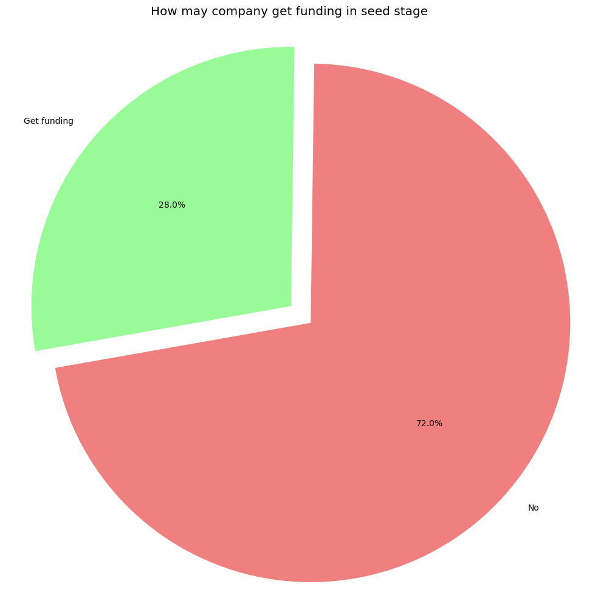

```python
## USA
plt.rcParams['figure.figsize'] =10,10
labels = ['No','Get funding']
sizes = df['get_funding_in_seed'].value_counts().tolist()
explode = (0, 0.1)
colors =  ['lightcoral','palegreen']

plt.pie(sizes, explode = explode, colors = colors ,labels=labels, autopct='%1.1f%%',
        shadow=False, startangle=190)
plt.axis('equal')
plt.tight_layout()
plt.title("How may company get funding in seed stage", fontdict=None, position= [0.48,1.1], size = 'x-large')

plt.show()
```

```python
## Remove Outlier first
Q1 = df['seed'][df['seed'] != 0].quantile(0.25)
Q3 = df['seed'][df['seed'] != 0].quantile(0.75)
IQR = Q3 - Q1

lower_bound = (Q1 - 1.5 * IQR)
upper_bound = (Q3 + 1.5 * IQR)
without_outlier = df[(df['seed'] > lower_bound ) & (df['seed'] < upper_bound)]
```

```python
Facebook_seed_funding = df['seed'][df['name']=="Facebook"].values[0]
Uber_seed_funding   = df['seed'][df['name']=="Uber"].values[0]
Dropbox_seed_funding   = df['seed'][df['name']=="Dropbox"].values[0]
```

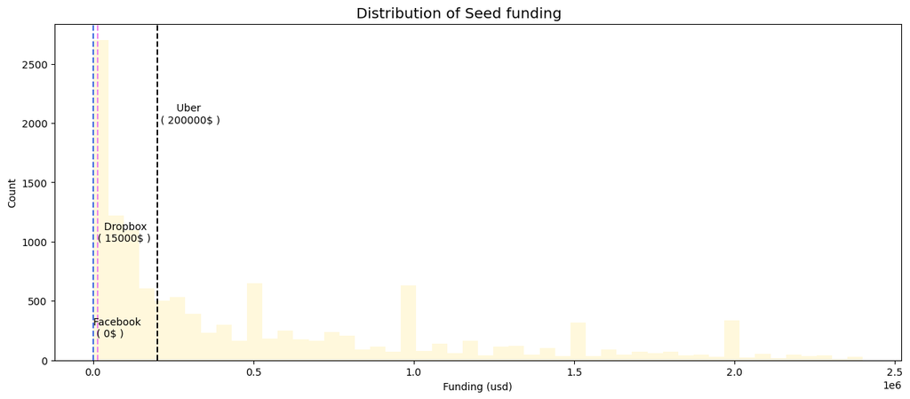

```python
plt.rcParams['figure.figsize'] = 15,6
plt.hist(without_outlier['seed'][without_outlier['seed']!=0].dropna(), bins=50,color = 'cornsilk' )

plt.axvline(Facebook_seed_funding,color='royalblue',linestyle ="--")
plt.text(Facebook_seed_funding+0.15, 200,"Facebook \n ( 0$ )")

plt.axvline(Uber_seed_funding,color='black',linestyle ="--")
plt.text(Uber_seed_funding+0.15, 2000,"      Uber \n ( 200000$ )")

plt.axvline(Dropbox_seed_funding,color='violet',linestyle ="--")
plt.text(Dropbox_seed_funding+0.15, 1000,"  Dropbox \n( 15000$ )")

plt.ylabel('Count')
plt.xlabel('Funding (usd)')
plt.title("Distribution of Seed funding ", fontdict=None, position= [0.48,1.05], size = 'x-large')
plt.show()
```

# Angel funding

Who is angel?

An angel investor (also known as a private investor, seed investor or angel funder) is a high net worth individual who provides financial backing for small startups or entrepreneurs, typically in exchange for ownership equity in the company. Often, angel investors are found among an entrepreneur's family and friends. The funds that angel investors provide may be a one-time investment to help the business get off the ground or an ongoing injection to support and carry the company through its difficult early stages.

```python
print("The average of Angel funding is around ",df['angel'][df['angel'] != 0].mean(), "$")
```

```
The average of Angel funding is around  1033615.6954298498 $
```

```python
df['get_funding_in_angel'] = df['angel'].map(lambda s :"Get funding"  if s > 0 else "Not get funding")
```

```python
print("Only " , df['get_funding_in_angel'].value_counts().values[1], " companies has angel investor")
print("while " , df['get_funding_in_angel'].value_counts().values[0], " are not")
print("~",df['get_funding_in_angel'].value_counts().values[1]/(df['get_funding_in_angel'].value_counts().values[1]+df['get_funding_in_angel'].value_counts().values[0]) *100, "percent")
```

```
Only  3129  companies has angel investor
while  46308  are not
~ 6.329267552642757 percent
```

Only 3129 companies has angel investor while 46308 are not ~ 6.329267552642757 percent

Investment in each round

```python
df['round_A'][df['round_A'] != 0].mean()
```

```
6830906.178162835
```

```python
df['round_B'][df['round_B'] != 0].mean()
```

```
13549761.864145402
```

```python
df['round_C'][df['round_C'] != 0].mean()
```

```
21004716.314416636
```

Those number above is average funding of each round of investment, you can see that the farther round the investment is higher too.

```python
round_ = ['round_A','round_B','round_C','round_D','round_E','round_F','round_G','round_H']
amount = [df['round_A'][df['round_A'] != 0].mean(),
          df['round_B'][df['round_B'] != 0].mean(),
          df['round_C'][df['round_C'] != 0].mean(),
          df['round_D'][df['round_D'] != 0].mean(),
          df['round_E'][df['round_E'] != 0].mean(),
          df['round_F'][df['round_F'] != 0].mean(),
          df['round_G'][df['round_G'] != 0].mean(),
         df['round_H'][df['round_H'] != 0].mean()]
```

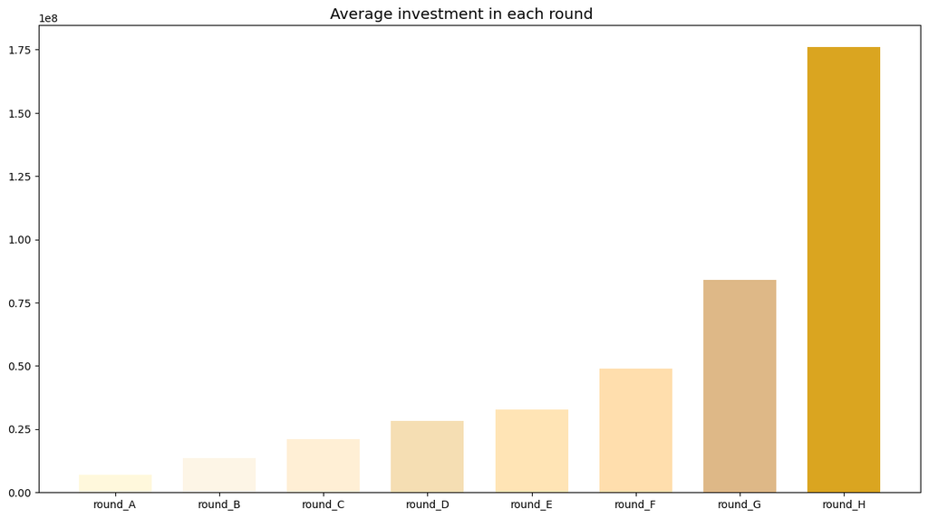

```python
plt.rcParams['figure.figsize'] = 15,8

height = amount
bars =  round_
y_pos = np.arange(len(bars))
plt.bar(y_pos, height , width=0.7, color= ['cornsilk','oldlace','papayawhip','wheat','moccasin','navajowhite','burlywood','goldenrod'] )
plt.xticks(y_pos, bars)
plt.title("Average investment in each round", fontdict=None, position= [0.48,1.05], size = 'x-large')
plt.show()
```

```python
# unique value in City
print("Number of Unique Values: ", (df['market'].nunique()))
print("Number of Missing Values: ", df['market'].isna().sum())
# Value Counts of top 10 cities
print((df['market'].value_counts()[0:10]))
```

```
Number of Unique Values:  753
Number of Missing Values:  3968
market
Software                4620
Biotechnology           3688
Mobile                  1983
E-Commerce              1805
Curated Web             1655
Enterprise Software     1280
Health Care             1207
Clean Technology        1200
Games                   1182
Hardware + Software     1081
Name: count, dtype: int64
```

```python
df
```

|  | permalink | name | homepage_url | category_list | market | funding_total_usd | status | country_code | state_code | region | ... | round_A | round_B | round_C | round_D | round_E | round_F | round_G | round_H | get_funding_in_seed | get_funding_in_angel |
| --- | --- | --- | --- | --- | --- | --- | --- | --- | --- | --- | --- | --- | --- | --- | --- | --- | --- | --- | --- | --- | --- |
| 0 | /organization/waywire | #waywire | http://www.waywire.com | \|Entertainment\|Politics\|Social Media\|News\| | News | 1750000.00 | acquired | USA | NY | New York City | ... | 0.00 | 0.00 | 0.00 | 0.00 | 0.00 | 0.00 | 0.00 | 0.00 | 1 | Not get funding |
| 1 | /organization/tv-communications | &TV Communications | http://enjoyandtv.com | \|Games\| | Games | 4000000.00 | operating | USA | CA | Los Angeles | ... | 0.00 | 0.00 | 0.00 | 0.00 | 0.00 | 0.00 | 0.00 | 0.00 | 0 | Not get funding |
| 2 | /organization/rock-your-paper | 'Rock' Your Paper | http://www.rockyourpaper.org | \|Publishing\|Education\| | Publishing | 40000.00 | operating | EST | NaN | Tallinn | ... | 0.00 | 0.00 | 0.00 | 0.00 | 0.00 | 0.00 | 0.00 | 0.00 | 1 | Not get funding |
| 3 | /organization/in-touch-network | (In)Touch Network | http://www.InTouchNetwork.com | \|Electronics\|Guides\|Coffee\|Restaurants\|Music\|i... | Electronics | 1500000.00 | operating | GBR | NaN | London | ... | 0.00 | 0.00 | 0.00 | 0.00 | 0.00 | 0.00 | 0.00 | 0.00 | 1 | Not get funding |
| 4 | /organization/r-ranch-and-mine | -R- Ranch and Mine | NaN | \|Tourism\|Entertainment\|Games\| | Tourism | 60000.00 | operating | USA | TX | Dallas | ... | 0.00 | 0.00 | 0.00 | 0.00 | 0.00 | 0.00 | 0.00 | 0.00 | 0 | Not get funding |
| ... | ... | ... | ... | ... | ... | ... | ... | ... | ... | ... | ... | ... | ... | ... | ... | ... | ... | ... | ... | ... | ... |
| 49433 | /organization/zzish | Zzish | http://www.zzish.com | \|Analytics\|Gamification\|Developer APIs\|iOS\|And... | Education | 320000.00 | operating | GBR | NaN | London | ... | 0.00 | 0.00 | 0.00 | 0.00 | 0.00 | 0.00 | 0.00 | 0.00 | 1 | Not get funding |
| 49434 | /organization/zznode-science-and-technology-co... | ZZNode Science and Technology | http://www.zznode.com | \|Enterprise Software\| | Enterprise Software | 1587301.00 | operating | CHN | NaN | Beijing | ... | 1587301.00 | 0.00 | 0.00 | 0.00 | 0.00 | 0.00 | 0.00 | 0.00 | 0 | Not get funding |
| 49435 | /organization/zzzzapp-com | Zzzzapp Wireless ltd. | http://www.zzzzapp.com | \|Web Development\|Advertising\|Wireless\|Mobile\| | Web Development | 97398.00 | operating | HRV | NaN | Split | ... | 0.00 | 0.00 | 0.00 | 0.00 | 0.00 | 0.00 | 0.00 | 0.00 | 1 | Not get funding |
| 49436 | /organization/a-list-games | [a]list games | http://www.alistgames.com | \|Games\| | Games | 9300000.00 | operating | NaN | NaN | NaN | ... | 0.00 | 0.00 | 0.00 | 0.00 | 0.00 | 0.00 | 0.00 | 0.00 | 1 | Not get funding |
| 49437 | /organization/x | [x+1] | http://www.xplusone.com/ | \|Enterprise Software\| | Enterprise Software | 45000000.00 | operating | USA | NY | New York City | ... | 16000000.00 | 10000000.00 | 0.00 | 0.00 | 0.00 | 0.00 | 0.00 | 0.00 | 0 | Not get funding |

49437 rows × 41 columns

```
Number of Missing Values:  8531
```

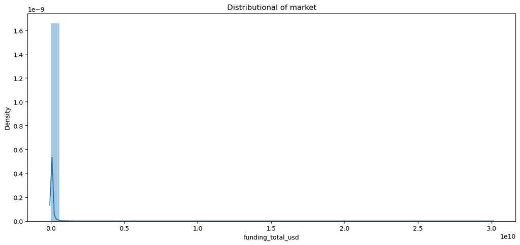

```python
#Plot of training_hours
print("Number of Missing Values: ", df['funding_total_usd'].isna().sum())
plt.figure(figsize=(14,6))
sns.distplot(df.funding_total_usd).set_title("Distributional of market");
```

# Feature Selection

Correlation in Data

```python
df_numeric = df.select_dtypes(include=['number'])  # Keep only numeric columns
correlation_matrix = df_numeric.corr()  # Compute correlation only on numeric columns
print(correlation_matrix)
```

```
                      funding_total_usd  funding_rounds  founded_year  seed  \
funding_total_usd                  1.00            0.11         -0.07 -0.00
funding_rounds                     0.11            1.00         -0.06  0.09
founded_year                      -0.07           -0.06          1.00  0.08
seed                              -0.00            0.09          0.08  1.00
venture                            0.21            0.40         -0.09 -0.01
equity_crowdfunding               -0.00           -0.00          0.01 -0.00
undisclosed                        0.02            0.03         -0.04 -0.00
convertible_note                   0.01            0.02         -0.01 -0.00
debt_financing                     0.90            0.02         -0.03 -0.00
angel                              0.00            0.06          0.02 -0.00
grant                              0.04            0.01         -0.09 -0.01
private_equity                     0.23            0.06         -0.06 -0.01
post_ipo_equity                    0.23            0.02         -0.04 -0.00
post_ipo_debt                      0.26           -0.00         -0.03 -0.00
secondary_market                   0.04            0.01         -0.01 -0.00
product_crowdfunding               0.00            0.02         -0.00  0.20
round_A                            0.06            0.17         -0.02  0.01
round_B                            0.10            0.28         -0.04  0.00
round_C                            0.13            0.30         -0.05 -0.00
round_D                            0.12            0.20         -0.03 -0.01
round_E                            0.11            0.20         -0.03 -0.01
round_F                            0.09            0.10         -0.01 -0.01
round_G                            0.08            0.06         -0.00 -0.00
round_H                            0.07            0.04         -0.00 -0.00
get_funding_in_seed               -0.05            0.03          0.27  0.33

                      venture  equity_crowdfunding  undisclosed  \
funding_total_usd        0.21                -0.00         0.02
funding_rounds           0.40                -0.00         0.03
founded_year            -0.09                 0.01        -0.04
seed                    -0.01                -0.00        -0.00
venture                  1.00                -0.01         0.01
equity_crowdfunding     -0.01                 1.00        -0.00
undisclosed              0.01                -0.00         1.00
convertible_note         0.00                -0.00        -0.00
debt_financing           0.01                -0.00        -0.00
angel                    0.01                 0.02         0.00
grant                    0.01                -0.00        -0.00
private_equity           0.06                -0.00         0.01
```

[output cut: 108 more lines]

```
post_ipo_equity                     -0.01
post_ipo_debt                       -0.01
secondary_market                    -0.01
product_crowdfunding                 0.00
round_A                             -0.07
round_B                             -0.08
round_C                             -0.07
round_D                             -0.03
round_E                             -0.03
round_F                             -0.02
round_G                             -0.01
round_H                             -0.00
get_funding_in_seed                  1.00

[25 rows x 25 columns]
```

```python
df.head()
```

|  | permalink | name | homepage_url | category_list | market | funding_total_usd | status | country_code | state_code | region | ... | round_A | round_B | round_C | round_D | round_E | round_F | round_G | round_H | get_funding_in_seed | get_funding_in_angel |
| --- | --- | --- | --- | --- | --- | --- | --- | --- | --- | --- | --- | --- | --- | --- | --- | --- | --- | --- | --- | --- | --- |
| 0 | /organization/waywire | #waywire | http://www.waywire.com | \|Entertainment\|Politics\|Social Media\|News\| | News | 1750000.00 | acquired | USA | NY | New York City | ... | 0.00 | 0.00 | 0.00 | 0.00 | 0.00 | 0.00 | 0.00 | 0.00 | 1 | Not get funding |
| 1 | /organization/tv-communications | &TV Communications | http://enjoyandtv.com | \|Games\| | Games | 4000000.00 | operating | USA | CA | Los Angeles | ... | 0.00 | 0.00 | 0.00 | 0.00 | 0.00 | 0.00 | 0.00 | 0.00 | 0 | Not get funding |
| 2 | /organization/rock-your-paper | 'Rock' Your Paper | http://www.rockyourpaper.org | \|Publishing\|Education\| | Publishing | 40000.00 | operating | EST | NaN | Tallinn | ... | 0.00 | 0.00 | 0.00 | 0.00 | 0.00 | 0.00 | 0.00 | 0.00 | 1 | Not get funding |
| 3 | /organization/in-touch-network | (In)Touch Network | http://www.InTouchNetwork.com | \|Electronics\|Guides\|Coffee\|Restaurants\|Music\|i... | Electronics | 1500000.00 | operating | GBR | NaN | London | ... | 0.00 | 0.00 | 0.00 | 0.00 | 0.00 | 0.00 | 0.00 | 0.00 | 1 | Not get funding |
| 4 | /organization/r-ranch-and-mine | -R- Ranch and Mine | NaN | \|Tourism\|Entertainment\|Games\| | Tourism | 60000.00 | operating | USA | TX | Dallas | ... | 0.00 | 0.00 | 0.00 | 0.00 | 0.00 | 0.00 | 0.00 | 0.00 | 0 | Not get funding |

5 rows × 41 columns

Splitting the data

```python
# Non_numerical_data
df.homepage_url
df.category_list
df.market
df.status
df.name
df.country_code
df.state_code
df.region
df.city
df.founded_at
```

```
0       2012-06-01
1              NaT
2       2012-10-26
3       2011-04-01
4       2014-01-01
           ...
49433   2013-01-28
49434          NaT
49435   2012-05-13
49436          NaT
49437   1999-01-01
Name: founded_at, Length: 49437, dtype: datetime64[ns]
```

```python
# Numerical Data
df.funding_total_usd
df.funding_rounds
df.first_funding_at
df.last_funding_at
df.seed
df.venture
df.equity_crowdfunding
df.undisclosed
df.convertible_note
df.debt_financing
df.angel
df.grant
df.private_equity
df.post_ipo_debt
df.secondary_market
df.product_crowdfunding
df.round_A
df.round_B
df.round_C
df.round_D
df.round_E
df.round_F
df.round_G
df.round_H
df.grant
```

```
0       0.00
1       0.00
2       0.00
3       0.00
4       0.00
        ...
49433   0.00
49434   0.00
49435   0.00
49436   0.00
49437   0.00
Name: grant, Length: 49437, dtype: float64
```

```python
# 'funding_total_usd',
# 'name','homepage_url','category_list','market','status', 'country_code', 'state_code' ,'region','city''founded_at' ,'founded_month' ,'founded_quarter','founded_year' , ,'first_funding_at' ,'last_funding_at'

df.grant
```

```
0       0.00
1       0.00
2       0.00
3       0.00
4       0.00
        ...
49433   0.00
49434   0.00
49435   0.00
49436   0.00
49437   0.00
Name: grant, Length: 49437, dtype: float64
```

```python
X=df[['funding_rounds', 'seed' ,'venture','equity_crowdfunding','undisclosed' ,'convertible_note' ,'debt_financing','angel', 'grant', 'private_equity' ,'post_ipo_equity', 'post_ipo_debt','secondary_market', 'product_crowdfunding', 'round_A' ,'round_B', 'round_C','round_D', 'round_E' ,'round_F' ,'round_G', 'round_H']]
y=df['grant']
```

```python
X_train, X_test, y_train, y_test = train_test_split(X, y, test_size=0.2, random_state=42)
```

```python
X_train.fillna(0)
X.fillna(0)
X_train.isnull().sum()
```

```
funding_rounds          0
seed                    0
venture                 0
equity_crowdfunding     0
undisclosed             0
convertible_note        0
debt_financing          0
angel                   0
grant                   0
private_equity          0
post_ipo_equity         0
post_ipo_debt           0
secondary_market        0
product_crowdfunding    0
round_A                 0
round_B                 0
round_C                 0
round_D                 0
round_E                 0
round_F                 0
round_G                 0
round_H                 0
dtype: int64
```

# Applying Models

Determine the baseline model accuracy

```python
# create baseline model
def baseline_model(n_predictions, value_to_predict):
    """
    just predict a single value (e.g. mean) for everything
    """
    baseline_preds = []
    for i in range(n_predictions):
        baseline_preds.append(value_to_predict)
    return pd.Series(baseline_preds)
```

```python
n_predictions = len(y_test)  # how many predictions to make? '3832'
baseline_value =pd.Series(y_train).value_counts().index[0]  # what value to predict? (classification = most common class '0.0')
baseline_preds = baseline_model(n_predictions, baseline_value)
baseline_preds = baseline_model(n_predictions, baseline_value)
baseline_preds
```

```
0      0.00
1      0.00
2      0.00
3      0.00
4      0.00
       ...
9883   0.00
9884   0.00
9885   0.00
9886   0.00
9887   0.00
Length: 9888, dtype: float64
```

```python
baseline_acc=accuracy_score(y_test, baseline_preds) #Accuracy score of baseline model
print('The baseline model accuracy score is :',baseline_acc)
```

```
The baseline model accuracy score is : 0.9765372168284789
```

# RandomForestClassifier Model

```python
# create and fit the RandomForestClassifier model
rfc=RandomForestClassifier()
rfc.fit(X_train, y_train)
# predict
pred = rfc.predict(X_test)
# pred
rfc_acc= accuracy_score(y_test, pred)
print('The accuracy score using the RandomForestClassifier (before resample) is :',rfc_acc)
print(classification_report(y_test, pred))
```

[output not shown]

[output cut: 180 more lines]

```
  27400000.0       0.00      0.00      0.00         1
  40000000.0       0.00      0.00      0.00         0
  45000000.0       0.00      0.00      0.00         1
  45100000.0       0.00      0.00      0.00         0
  50000000.0       0.00      0.00      0.00         2
  71600000.0       0.00      0.00      0.00         0
  90000000.0       1.00      1.00      1.00         2
 154053900.0       0.00      0.00      0.00         0
 170000000.0       0.00      0.00      0.00         1
 191000000.0       0.00      0.00      0.00         1
 206000000.0       0.00      0.00      0.00         0

    accuracy                           0.99      9888
   macro avg       0.15      0.16      0.15      9888
weighted avg       0.98      0.99      0.98      9888
```

# DecisionTreeClassifier Model

```python
# create and fit DecisionTreeClassifier model
dtc=DecisionTreeClassifier()
dtc.fit(X_train,y_train)
#predict
pred = dtc.predict(X_test)
# pred

dtc_acc= accuracy_score(y_test, pred)
print('The accuracy score with using the decision tree classifier is :',dtc_acc)

print(classification_report(y_test, pred))
```

```
The accuracy score with using the decision tree classifier is : 0.9894822006472492
              precision    recall  f1-score   support

         0.0       1.00      1.00      1.00      9656
      1003.0       0.00      0.00      0.00         0
      1700.0       0.00      0.00      0.00         1
      1840.0       0.00      0.00      0.00         0
      2000.0       0.00      0.00      0.00         2
      2393.0       0.00      0.00      0.00         0
      2500.0       0.00      0.00      0.00         1
     10000.0       0.67      1.00      0.80         2
     10009.0       0.00      0.00      0.00         1
     12500.0       0.00      0.00      0.00         0
     13000.0       0.00      0.00      0.00         2
     13300.0       0.00      0.00      0.00         0
     14852.0       0.00      0.00      0.00         1
     15000.0       0.50      1.00      0.67         1
     17215.0       0.00      0.00      0.00         0
     18000.0       0.00      0.00      0.00         1
     18394.0       0.00      0.00      0.00         1
     20000.0       1.00      1.00      1.00         1
     25000.0       1.00      1.00      1.00         7
     26000.0       0.00      0.00      0.00         0
     26500.0       0.00      0.00      0.00         1
     29000.0       0.00      0.00      0.00         1
     30000.0       0.67      1.00      0.80         2
     31777.0       0.00      0.00      0.00         1
     32094.0       0.00      0.00      0.00         0
     32521.0       0.00      0.00      0.00         0
     32707.0       0.00      0.00      0.00         1
     34060.0       1.00      1.00      1.00         1
     35000.0       1.00      1.00      1.00         2
     39700.0       0.00      0.00      0.00         1
     40000.0       0.86      1.00      0.92         6
     43823.0       1.00      1.00      1.00         1
     45000.0       1.00      1.00      1.00         1
     45412.0       0.00      0.00      0.00         1
     45457.0       0.00      0.00      0.00         1
     45685.0       0.00      0.00      0.00         0
     47500.0       0.00      0.00      0.00         1
```

[output cut: 172 more lines]

```
  26000000.0       0.50      1.00      0.67         1
  27400000.0       0.00      0.00      0.00         1
  40000000.0       0.00      0.00      0.00         0
  45000000.0       0.00      0.00      0.00         1
  45100000.0       0.00      0.00      0.00         0
  50000000.0       0.00      0.00      0.00         2
  90000000.0       1.00      1.00      1.00         2
 154053900.0       0.00      0.00      0.00         0
 170000000.0       0.00      0.00      0.00         1
 191000000.0       0.00      0.00      0.00         1
 206000000.0       0.00      0.00      0.00         0

    accuracy                           0.99      9888
   macro avg       0.23      0.25      0.23      9888
weighted avg       0.99      0.99      0.99      9888
```

KNeighborsClassifier Model

```python
# create and fit KNeighborsClassifier model
knn = KNeighborsClassifier(n_neighbors=3)
knn.fit(X_train,y_train)

#predict
pred = knn.predict(X_test)

# #KNN accuracy score
Knn_acc= accuracy_score(y_test, knn.predict(X_test))
print('The accuracy socre using the KNeighborsClassifier is :',Knn_acc)

print(classification_report(y_test, pred))
```

```
The accuracy socre using the KNeighborsClassifier is : 0.9841221682847896
              precision    recall  f1-score   support

         0.0       0.99      1.00      1.00      9656
      1700.0       0.00      0.00      0.00         1
      1840.0       0.00      0.00      0.00         0
      2000.0       0.00      0.00      0.00         2
      2200.0       0.00      0.00      0.00         0
      2500.0       0.00      0.00      0.00         1
      3000.0       0.00      0.00      0.00         0
     10000.0       1.00      1.00      1.00         2
     10009.0       0.00      0.00      0.00         1
     12000.0       0.00      0.00      0.00         0
     13000.0       0.00      0.00      0.00         2
     14852.0       0.00      0.00      0.00         1
     15000.0       1.00      1.00      1.00         1
     18000.0       0.00      0.00      0.00         1
     18394.0       0.00      0.00      0.00         1
     20000.0       0.33      1.00      0.50         1
     21466.0       0.00      0.00      0.00         0
     25000.0       0.60      0.43      0.50         7
     26500.0       0.00      0.00      0.00         1
     29000.0       0.00      0.00      0.00         1
     30000.0       0.00      0.00      0.00         2
     31777.0       0.00      0.00      0.00         1
     32521.0       0.00      0.00      0.00         0
     32707.0       0.00      0.00      0.00         1
     33283.0       0.00      0.00      0.00         0
     34060.0       0.00      0.00      0.00         1
     35000.0       0.50      0.50      0.50         2
     39700.0       0.00      0.00      0.00         1
     40000.0       0.67      0.67      0.67         6
     42000.0       0.00      0.00      0.00         0
     43000.0       0.00      0.00      0.00         0
     43823.0       0.00      0.00      0.00         1
     45000.0       0.00      0.00      0.00         1
     45412.0       0.00      0.00      0.00         1
     45457.0       0.00      0.00      0.00         1
     45685.0       0.00      0.00      0.00         0
     47500.0       0.00      0.00      0.00         1
```

[output cut: 147 more lines]

```
  26000000.0       0.00      0.00      0.00         1
  27400000.0       0.00      0.00      0.00         1
  39700000.0       0.00      0.00      0.00         0
  45000000.0       0.00      0.00      0.00         1
  45100000.0       0.00      0.00      0.00         0
  50000000.0       0.00      0.00      0.00         2
  90000000.0       1.00      1.00      1.00         2
 145750000.0       0.00      0.00      0.00         0
 154053900.0       0.00      0.00      0.00         0
 170000000.0       0.00      0.00      0.00         1
 191000000.0       0.00      0.00      0.00         1

    accuracy                           0.98      9888
   macro avg       0.13      0.15      0.13      9888
weighted avg       0.98      0.98      0.98      9888
```